# BIOSTAT 620 Homework 4: HPC, SGL and Interactive plots

Author

Faith Okaalo

Published

March 29, 2026

Load required libraries

```r
library(microbenchmark)
library (ggplot2)
library(parallel)
library (patchwork)
library(plotly)
library(dplyr)
```

# **HPC**

For Questions 1-2, rewrite the provided R functions to make them faster. It is OK (and recommended) to take a look at StackOverflow and Google.

Using the synthetic dataset provided, show that your new function returns the same output as the original function. Then use `microbenchmark` to show that your version is faster and provide a visualization of the runtimes.

### **Question 1 (6 points)**

- `fun2`: Calculate the running (cumulative) total along each row of a numeric matrix. Output should be a matrix with dimensions equal to the input matrix.

```r
# running cumulative sum by row
fun2 <- function(mat) {
  n <- nrow(mat)
  k <- ncol(mat)
  ans <- mat
  for (i in 1:n) {
    for (j in 2:k) {
      ans[i,j] <- mat[i, j] + ans[i, j - 1]
    }
  }
  ans
}

fun2alt <- function(mat) {
  t(apply(mat, 1, cumsum))
}
```

**Generate and test using the following synthetic data (`dat`):**

```r
# Generate data
set.seed(2315)
dat <- matrix(rnorm(200 * 100), nrow = 200)

# Verify same output
all.equal(fun2(dat), fun2alt(dat))
```

```
[1] TRUE
```

```r
# Benchmark
mb1 <- microbenchmark(
  Original  = fun2(dat),
  Optimized = fun2alt(dat),
  times = 100
)
print(mb1)
```

```
Unit: microseconds
      expr     min       lq     mean   median        uq      max neval cld
  Original 802.801 858.5510 1095.459 924.7510 1092.7510 2731.401   100  a
 Optimized 272.101 314.0005  487.332 425.7015  475.5515 3837.401   100   b
```

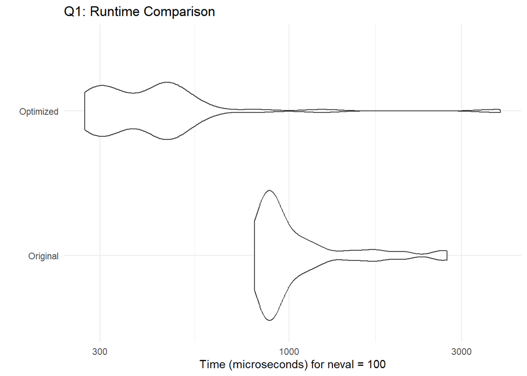

```r
autoplot(mb1) + labs(title = "Q1: Runtime Comparison") + theme_minimal()
```

### **Question 2 (8 points)**

- `fun3`: Calculate the running (cumulative) total of a vector, where the sum resets when a zero is encountered.

```r
fun3 <- function(x) {
  out <- numeric(length(x))
  cumsum_x <- 0
  for (i in seq_along(x)) {
    if (x[i] == 0) {
      cumsum_x <- 0
    } else {
      cumsum_x <- cumsum_x + x[i]
    }
    out[i] <- cumsum_x
  }
  out
}


fun3alt <- function(x) {
  cs <- cumsum(x)
  zero_pos <- which(x == 0)
  if (length(zero_pos) == 0) return(cs)
  offsets <- c(0, cs)[zero_pos]
  offset_vec <- numeric(length(x))
  offset_vec[zero_pos] <- offsets
  cs - cummax(offset_vec)
}

# Generate data
set.seed(42)
x_test <- sample(0:5, 10000, replace = TRUE)

# Verify same output
all.equal(fun3(x_test), fun3alt(x_test))
```

```
[1] TRUE
```

```r
# Benchmark
mb2 <- microbenchmark(
  Original  = fun3(x_test),
  Optimized = fun3alt(x_test),
  times = 100
)
print(mb2)
```

```
Unit: microseconds
      expr     min       lq     mean   median      uq      max neval cld
  Original 405.301 455.2015 507.8791 468.0010 491.601 1405.601   100  a
 Optimized  77.601 177.8510 233.5830 190.4515 211.451 3046.401   100   b
```

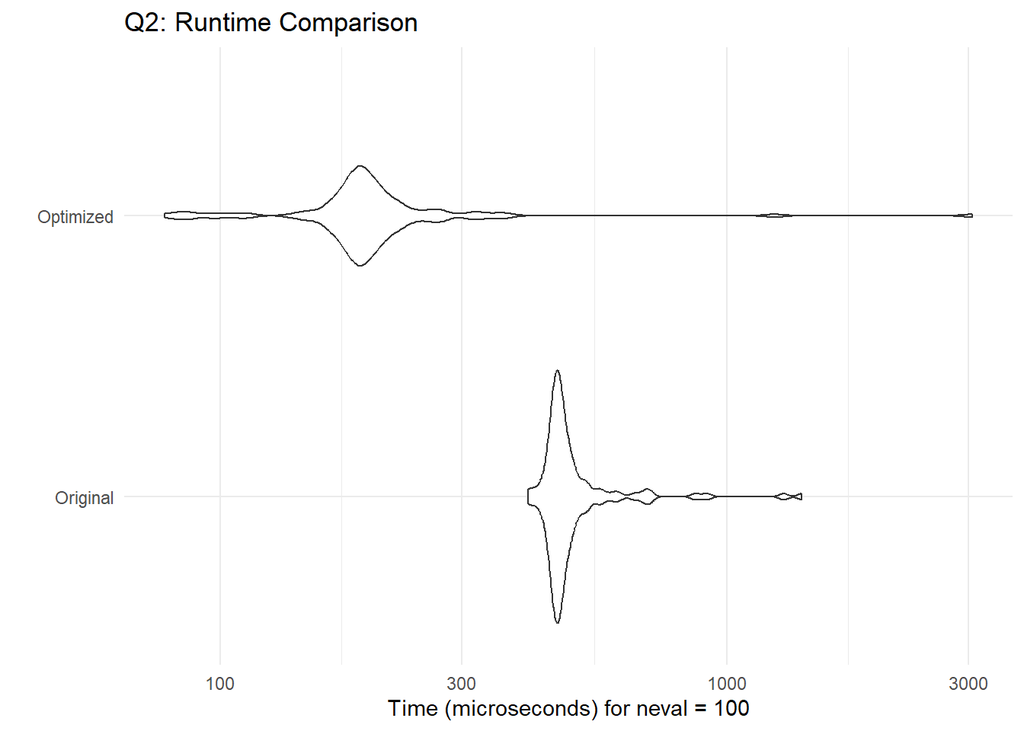

```r
autoplot(mb2) + labs(title = "Q2: Runtime Comparison") + theme_minimal()
```

### **Question 3 (12 points)**

For this question, we will ask you to parallelize a process for computationally estimating the value of pi

The following function allows us to estimate pi through a simple simulation:

```r
# serial
sim_pi <- function(n = 1000, i = NULL) {
  p <- matrix(runif(n * 2), ncol = 2)
  mean(rowSums(p^2) < 1) * 4
}

# Serial version
set.seed(1231)
time_serial <- system.time({
  ans_serial <- unlist(lapply(1:4000, sim_pi, n = 10000))
  print(mean(ans_serial))
})
```

```
[1] 3.14124
```

```r
print(time_serial)
```

```
   user  system elapsed
   1.12    0.02    1.17
```

```r
# Parallelize
cl <- makeCluster(detectCores())
clusterSetRNGStream(cl, 1231)

time_parallel <- system.time({
  ans_parallel <- unlist(parLapply(cl, 1:4000, sim_pi, n = 10000))
  print(mean(ans_parallel))
})
```

```
[1] 3.141144
```

```r
stopCluster(cl)
print(time_parallel)
```

```
   user  system elapsed
   0.00    0.01    0.58
```

**Visualization**

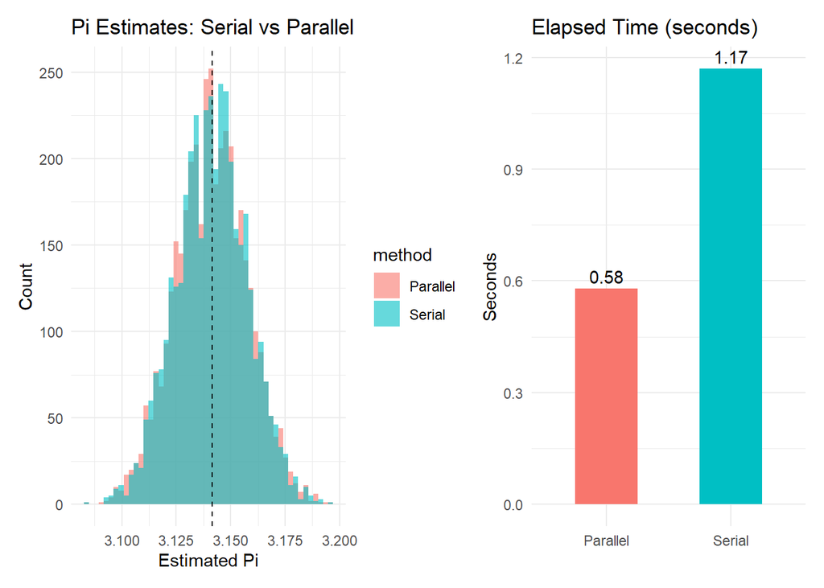

```r
# Plot 1: similar estimate distributions
results_df <- data.frame(
  estimate = c(ans_serial, ans_parallel),
  method   = rep(c("Serial", "Parallel"), each = 4000)
)

p1 <- ggplot(results_df, aes(x = estimate, fill = method)) +
  geom_histogram(bins = 50, alpha = 0.6, position = "identity") +
  geom_vline(xintercept = pi, linetype = "dashed") +
  labs(title = "Pi Estimates: Serial vs Parallel", x = "Estimated Pi", y = "Count") +
  theme_minimal()

# Plot 2: runtime comparison
timing_df <- data.frame(
  method  = c("Serial", "Parallel"),
  elapsed = c(time_serial["elapsed"], time_parallel["elapsed"])
)

p2 <- ggplot(timing_df, aes(x = method, y = elapsed, fill = method)) +
  geom_col(width = 0.5, show.legend = FALSE) +
  geom_text(aes(label = round(elapsed, 2)), vjust = -0.4) +
  labs(title = "Elapsed Time (seconds)", x = NULL, y = "Seconds") +
  theme_minimal()

p1 + p2
```

# **SQL**

```r
library(RSQLite)
library(DBI)

con <- dbConnect(SQLite(), ":memory:")
surveys <- read.csv("C:/Users/faith/Downloads/surveys.csv")
species  <- read.csv("C:/Users/faith/Downloads/species.csv")
plots    <- read.csv("C:/Users/faith/Downloads/plots.csv")

dbWriteTable(con, "surveys", surveys, overwrite = TRUE)
dbWriteTable(con, "species",  species,  overwrite = TRUE)
dbWriteTable(con, "plots",    plots,    overwrite = TRUE)
```

## **Question 4 (6 points)**

First, using the approach from Lab 9, create a query to to see the structure of the surveys table. Then, using the surveys table, write a query to display the three date fields, species_id, and weight in kilograms (rounded to two decimal places), for individuals captured in 1999, ordered alphabetically by the species_id.

```r
dbGetQuery(con, "PRAGMA table_info(surveys)")
```

```
  cid            name    type notnull dflt_value pk
1   0       record_id INTEGER       0         NA  0
2   1           month INTEGER       0         NA  0
3   2             day INTEGER       0         NA  0
4   3            year INTEGER       0         NA  0
5   4         plot_id INTEGER       0         NA  0
6   5      species_id    TEXT       0         NA  0
7   6             sex    TEXT       0         NA  0
8   7 hindfoot_length INTEGER       0         NA  0
9   8          weight INTEGER       0         NA  0
```

```sql
SELECT month, day, year, species_id,
       ROUND(weight / 1000.0, 2) AS weight_kg
FROM surveys
WHERE year = 1999
ORDER BY species_id ASC;
```

Displaying records 1 - 10

| month | day | year | species_id | weight_kg |
| --- | --- | --- | --- | --- |
| 1 | 17 | 1999 |  | NA |
| 2 | 21 | 1999 |  | NA |
| 2 | 21 | 1999 |  | NA |
| 2 | 21 | 1999 |  | NA |
| 3 | 15 | 1999 |  | NA |
| 3 | 15 | 1999 |  | NA |
| 3 | 15 | 1999 |  | NA |
| 4 | 17 | 1999 |  | NA |
| 4 | 18 | 1999 |  | NA |
| 4 | 18 | 1999 |  | NA |

## **Question 5 (6 points)**

Write a query that returns: the total weight, average weight, minimum and maximum weights for all animals caught over the duration of the survey. Can you modify it so that it outputs these values only for weights between 5 and 10 inclusive?

**Total weight, average weight, minimum and maximum weights for all animals caught over the duration of the survey.**

```sql
SELECT SUM(weight)  AS total_weight,
       AVG(weight)  AS avg_weight,
       MIN(weight)  AS min_weight,
       MAX(weight)  AS max_weight
FROM surveys;
```

1 records

| total_weight | avg_weight | min_weight | max_weight |
| --- | --- | --- | --- |
| 1377594 | 42.67243 | 4 | 280 |

**Weights between 5 and 10 inclusive**

```sql
SELECT SUM(weight)  AS total_weight,
       AVG(weight)  AS avg_weight,
       MIN(weight)  AS min_weight,
       MAX(weight)  AS max_weight
FROM surveys
WHERE weight BETWEEN 5 AND 10;
```

1 records

| total_weight | avg_weight | min_weight | max_weight |
| --- | --- | --- | --- |
| 24874 | 8.392038 | 5 | 10 |

## **Question 6 (8 points)**

Write a single query that returns:

1. How many were counted each year, for each different species
2. The average weights of each species in each year

Show the result and also store the resulting SQL data table as an R object. Hint, use the R function `DBI::dbGetQuery`. Note: to do so, you may need to, rather than running a SQL chunk, call SQL within an R chunk.

```r
q6_result <- DBI::dbGetQuery(con, "
  SELECT year, species_id,
         COUNT(*)    AS n_captured,
         AVG(weight) AS avg_weight
  FROM surveys
  GROUP BY year, species_id
  ORDER BY year, species_id;
")

head(q6_result, 20)
```

```
   year species_id n_captured avg_weight
1  1977                    16         NA
2  1977         DM        264  41.141304
3  1977         DO         12  42.666667
4  1977         DS         98 121.437500
5  1977         NL         31         NA
6  1977         OL         10  21.666667
7  1977         OT         17  21.000000
8  1977         OX          7  21.333333
9  1977         PE          6  19.500000
10 1977         PF         31   7.173913
11 1977         PP          7  15.333333
12 1977         RM          2  10.000000
13 1977         SH          1         NA
14 1977         SS          1         NA
15 1978                    56         NA
16 1978         AH          1         NA
17 1978         DM        389  40.795455
18 1978         DO         22  45.000000
19 1978         DS        320 115.198653
20 1978         NL         48 184.656250
```

## **Question 7 (8 points)**

Write a query that returns, from the species table, the number of species in each taxa, only for the taxa with more than 10 species.

```sql
SELECT taxa, COUNT(species_id) AS n_species
FROM species
GROUP BY taxa
HAVING n_species > 10
ORDER BY n_species DESC;
```

2 records

| taxa | n_species |
| --- | --- |
| Rodent | 31 |
| Bird | 13 |

## **Question 8 (10 points)**

Write a query that returns the number of animals caught of each genus in each plot. Order the results by plot number (ascending) and by descending number of individuals in each plot. Show the result and also store the resulting SQL data table as an R object.

```r
q8_result <- DBI::dbGetQuery(con, "
  SELECT sv.plot_id, sp.genus,
         COUNT(*) AS n_individuals
  FROM surveys AS sv
  INNER JOIN species AS sp ON sv.species_id = sp.species_id
  GROUP BY sv.plot_id, sp.genus
  ORDER BY sv.plot_id ASC, n_individuals DESC;
")

head(q8_result, 20)
```

```
   plot_id            genus n_individuals
1        1        Dipodomys          1330
2        1      Chaetodipus           332
3        1        Onychomys           153
4        1          Neotoma            54
5        1      Perognathus            34
6        1       Peromyscus            28
7        1  Reithrodontomys            24
8        1     Spermophilus            12
9        1       Amphispiza             7
10       1 Ammospermophilus             7
11       1           Pipilo             4
12       1       Sylvilagus             2
13       1           Rodent             1
14       1          Baiomys             1
15       2        Dipodomys          1032
16       2      Chaetodipus           358
17       2        Onychomys           264
18       2          Neotoma           201
19       2       Peromyscus           182
20       2  Reithrodontomys            73
```

## **Question 9 (8 points)**

How many specimens of each species were captured in each type of plot, excluding specimens of unknown species?

```sql
SELECT pl.plot_type, sv.species_id, COUNT(*) AS n_specimens
FROM surveys AS sv
INNER JOIN plots AS pl ON sv.plot_id = pl.plot_id
WHERE sv.species_id IS NOT NULL
  AND sv.species_id != 'SP'
GROUP BY pl.plot_type, sv.species_id
ORDER BY pl.plot_type, n_specimens DESC;
```

Displaying records 1 - 10

| plot_type | species_id | n_specimens |
| --- | --- | --- |
| Control | DM | 6760 |
| Control | DO | 1671 |
| Control | DS | 1389 |
| Control | PP | 1108 |
| Control | OT | 1004 |
| Control | PB | 789 |
| Control | NL | 610 |
| Control | OL | 471 |
| Control | PF | 424 |
| Control | RM | 403 |

## **Question 10 (8 points)**

Write a query that finds the average weight of each rodent species (i.e., only include species with Rodent in the taxa field).

```sql
SELECT sv.species_id, sp.genus, sp.species,
       ROUND(AVG(sv.weight), 2) AS avg_weight_g
FROM surveys AS sv
INNER JOIN species AS sp ON sv.species_id = sp.species_id
WHERE sp.taxa = 'Rodent'
  AND sv.weight IS NOT NULL
GROUP BY sv.species_id
ORDER BY avg_weight_g DESC;
```

Displaying records 1 - 10

| species_id | genus | species | avg_weight_g |
| --- | --- | --- | --- |
| NL | Neotoma | albigula | 159.25 |
| DS | Dipodomys | spectabilis | 120.13 |
| SS | Spermophilus | spilosoma | 93.50 |
| SH | Sigmodon | hispidus | 73.15 |
| SF | Sigmodon | fulviventer | 58.88 |
| SO | Sigmodon | ochrognathus | 55.41 |
| DO | Dipodomys | ordii | 48.87 |
| DM | Dipodomys | merriami | 43.16 |
| PB | Chaetodipus | baileyi | 31.74 |
| OL | Onychomys | leucogaster | 31.58 |

## **Question 11 (10 points)**

Using `plotly::ggplotly` and the data table resultant from question 8, make an interactive grouped bar chart of the number of species by plot id, subseting to plot id 1-5.

```r
q8_sub <- q8_result %>%
  filter(plot_id %in% 1:5) %>%
  mutate(plot_id = factor(plot_id))

p_bar <- ggplot(q8_sub, aes(x = plot_id, y = n_individuals, fill = genus)) +
  geom_col(position = "dodge") +
  labs(title = "Individuals by Genus for Plots 1-5",
       x = "Plot ID", y = "Count", fill = "Genus") +
  theme_minimal()

ggplotly(p_bar)
```

[interactive chart not shown]

## **Question 12 (10 points)**

Using native `plotly` functions (no `ggplot2`) and the data table resultant from question 6, make an interactive line chart of average species weight over time for each species. Make sure to properly handle missing data. Can you do anything to reduce the noise in your plot?

```r
q6_clean <- q6_result %>%
  filter(!is.na(avg_weight))

species_keep <- q6_clean %>%
  group_by(species_id) %>%
  summarise(n_years = n_distinct(year)) %>%
  #  Noise reduced by keeping only species observed in at least 10 different years
  filter(n_years >= 10) %>%
  pull(species_id)

q6_filtered <- q6_clean %>%
  filter(species_id %in% species_keep)

plot_ly(q6_filtered,
        x = ~year,
        y = ~avg_weight,
        color = ~species_id,
        type  = "scatter",
        mode  = "lines+markers",
        connectgaps = FALSE) %>%
  layout(
    title = "Average Weight Over Time by Species",
    xaxis = list(title = "Year"),
    yaxis = list(title = "Average Weight (g)")
  )
```

[interactive chart not shown]